# Practice 1

Anastasia Hernández y Alán Muñoz

February 15, 2016

2.1) Ejemplo de aminoácido con cadena lateral aromática

[figure not shown]

2.2) Ejemplo de aminoácido con cadena lateral chica

[figure not shown]

2.3) Ejemplo de giro en torno a los ángulos phi/psi de un residuo seleccionado, que pasa cuando si sus vecinos tienen cadenas laterales voluminosas?

= Si sus vecinos tienen cadenas laterales voluminosas, al realizar el giro se pueden observar choques entre el residuo que lo realiza y los demás, provocando ‘clashes’ entre ellos.

[figure not shown]

[figure not shown]

2.4) Ejemplo de puentes de hidrógeno entre resíduos de una alfa-hélice y entre hojas de una lámina beta. Desde el punto de vista algorítmico, cuál de los estados de estructura secundaria les parece más difícil de programar?

= De los estados de estructura secundaria, sería más dificil de programar a las alfa-hélices, ya que no puede predecirse con las sustancias o estructuras a su alrededor; a diferencia de las beta-plegadas que son más fácilmente reconocidas por su relación muy cercana con estructuras como los puentes de hidrógeno.

[figure not shown]

[figure not shown]

2.5) Ejemplo de residuo hidrofóbico expuesto y luego correctamente “enterrado” tras operaciones con los vecinos.

[figure not shown]

[figure not shown]

2.6) Ejemplo de conformaciones distintas con puntuaciones similares, para hacer patente el problema de evaluar lo correcto de una conformación.

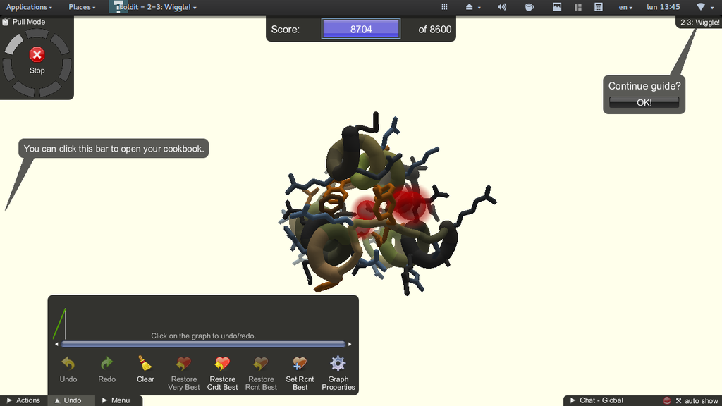

[figure not shown]

2.7) De acuerdo con http://eead-csic-compbio.github.io/bioinformatica_estructural/node17.html calcula el tiempo que llevaría explorar todas las conformaciones posibles de uno de los péptidos o proteínas que utilicen en los puzzles.

Tiempo para explorar todos los estados:

```r
Texp=(10^13)*(17^100)
Texp
```

```
## [1] 1.108899e+136
```

[figure not shown]

Nivel obtenido en el programa

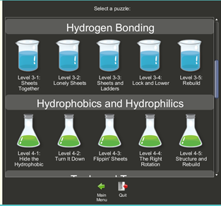